# GRSM Macroinverts Stream Indices - EPT & NCBI

John Grady

2025-10-14

Macroinvertebrates in GRSM - EPT & NCBI Insect orders Ephemeroptera (mayflies), Plecoptera (stoneflies) and Trichoptera (caddisflies) are indicators of higher stream quality. Total EPT richness (number of taxa) or abundance weighted indices like NCBI can be used to evaulate stream quality

First load libraries and plotting code

```r
library(tidyverse)
library(RColorBrewer)
library(readxl)
library(viridisLite)

theme_plot <- function(legend = TRUE) {
  ggplot2::theme(
    panel.grid        = element_blank(),
    aspect.ratio      = .75,
    axis.text         = element_text(size = 18, color = "black"),
    axis.ticks.length = unit(0.2, "cm"),
    axis.title        = element_text(size = 18),
    axis.title.y      = element_text(margin = margin(r = 10)),
    axis.title.x      = element_text(margin = margin(t = 10)),
    axis.title.x.top  = element_text(margin = margin(b = 5)),
    plot.title        = element_text(size = 18, face = "plain", hjust = 10),
    panel.border      = element_rect(colour = "black", fill = NA, linewidth = 1),
    panel.background  = element_blank(),
    strip.background  = element_blank(),
    legend.text       = element_text(size = 15),
    legend.title      = element_text(size = 18),
    legend.position   = if (legend) "right" else "none",
    text              = element_text(family = "Helvetica")
  )
}
```

Add data from directory

```r
# Base directory (adjust as needed)
base_dir <- "/Users/jgradym/Library/CloudStorage/GoogleDrive-jgradym@gmail.com/Shared drives/GRSM_CESU/Maine"

# File paths
inverts_path <- file.path(base_dir, "Data", "Aquatics_Macroinverts", "SummaryData", "Specimen_Data_Export.csv")
ncbi_path    <- file.path(base_dir, "Data", "Aquatics_Macroinverts", "NCBI", "NCBI_taxa.xlsx")

# Read
inverts <- readr::read_csv(inverts_path)
ncbi    <- readxl::read_xlsx(ncbi_path)

# Trim character whitespace
inverts <- inverts %>%
  mutate(across(everything(), ~ if (is.character(.x)) trimws(.x) else .x))

# Parse helpers
inverts$Location <- stringr::word(inverts$LOC_NAME, 1, sep = ",")
inverts$Site     <- stringr::word(inverts$LOC_NAME, 2, sep = ",")
inverts$Genus    <- stringr::word(inverts$Lab_Scientific_Name, 1, sep = " ")
inverts$Year     <- as.numeric(stringr::word(inverts$Start_Date, 1, sep = "-"))
```

To get EPT per stream, first get EPT per site, then average per stream

```r
ept_site_year <- inverts %>%
  group_by(Location, Site, Year) %>%
  summarize(
    E_rich   = n_distinct(Genus[Lab_Order == "Ephemeroptera"], na.rm = TRUE),
    P_rich   = n_distinct(Genus[Lab_Order == "Plecoptera"],   na.rm = TRUE),
    T_rich   = n_distinct(Genus[Lab_Order == "Trichoptera"],  na.rm = TRUE),
    EPT_rich = E_rich + P_rich + T_rich,
    .groups  = "drop"
  )

ept_stream_year <- ept_site_year %>%
  group_by(Location, Year) %>%
  summarize(
    E_rich   = mean(E_rich,   na.rm = TRUE),
    P_rich   = mean(P_rich,   na.rm = TRUE),
    T_rich   = mean(T_rich,   na.rm = TRUE),
    EPT_rich = mean(EPT_rich, na.rm = TRUE),
    n_sites  = dplyr::n_distinct(Site),
    .groups  = "drop"
  )
```

Specify minimum number of sample years to consider

```r
n_years_min <- 5
streams_enough_years <- ept_stream_year %>%
  group_by(Location) %>%
  filter(dplyr::n_distinct(Year) >= n_years_min) %>%
  ungroup()

n_streams      <- length(unique(streams_enough_years$Location))
stream_palette <- viridisLite::turbo(n_streams)
```

Plot EPT - Total number of genera from EPT per stream over time Plotted threshold for quality are given in reference for unspecified EPT “taxa” in NC mountains Here we use genera, which will produce a lower value than species. Threshold may not be accurate.

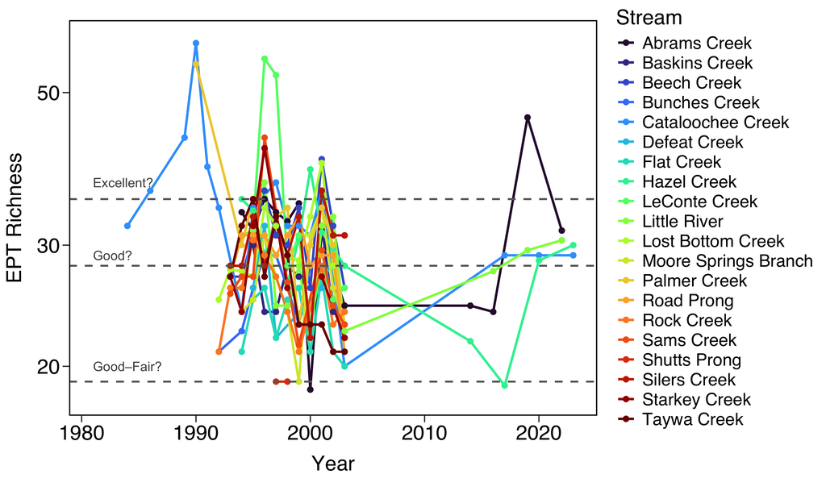

```r
ggplot(
  streams_enough_years %>% filter(EPT_rich > 0),
  aes(x = Year, y = EPT_rich, color = Location, group = Location)
) +
  geom_line(linewidth = 1) +
  geom_point(size = 2) +
  scale_color_manual(values = stream_palette, name = "Stream") +
  scale_y_log10(limits = c(18, 60)) +
  labs(x = "Year", y = "EPT Richness") +
  geom_hline(yintercept = c(35, 28, 19), color = "grey40", linetype = "dashed", linewidth = 0.8) +
  annotate("text", x = 1981, y = 37, label = "Excellent?",  color = "grey30", size = 4, hjust = 0) +
  annotate("text", x = 1981, y = 29, label = "Good?",       color = "grey30", size = 4, hjust = 0) +
  annotate("text", x = 1981, y = 20, label = "Good–Fair?",  color = "grey30", size = 4, hjust = 0) +
  theme_plot()
```

NCBI is the North Carolina Biotic Index that includes abundance data to give a biotic index for stream quality. We add a file on species-level NCBI values to our GRSM stream dataset. We average species to get a genus level NCBI. We average genera to get a site level value. Then we average sites per stream to get a stream level NCBI value. Thresholds for stream quality are shown

The formula is NCBI = (NCBI_value_per_taxa X taxa_abundance)/total_invert_abundance)

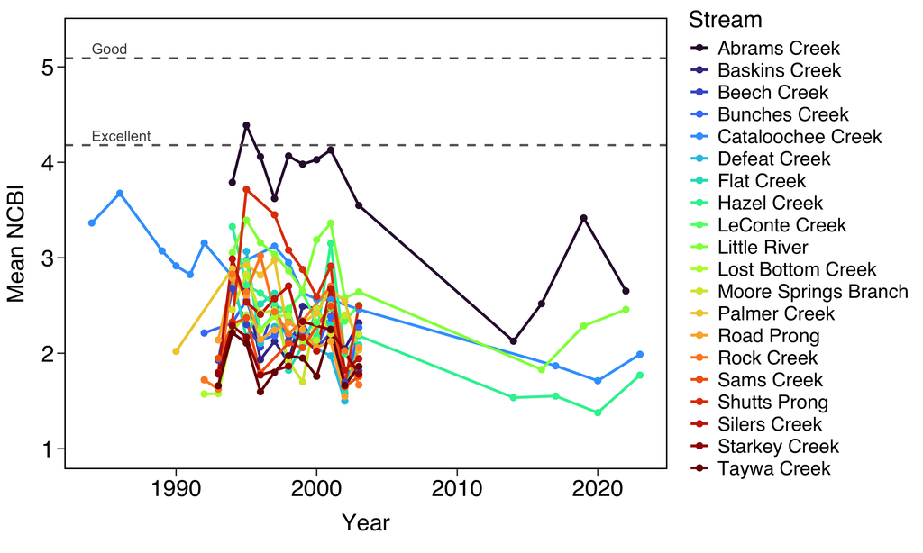

```r
ncbi$Genus <- stringr::word(ncbi$Species, 1, sep = " ")

ncbi_genus <- ncbi %>%
  group_by(Genus) %>%
  summarize(genus_ncbi = mean(NCBI, na.rm = TRUE), .groups = "drop")

inv_join <- inverts %>%
  dplyr::left_join(ncbi_genus, by = "Genus")

# Join totals so you can compute coverage
totals <- inv_join %>%
  dplyr::group_by(Location, Site, Year) %>%
  dplyr::summarize(counts_total = sum(Count, na.rm = TRUE), .groups = "drop")

# Scored-only NCBI
ncbi_site_year <- inv_join %>%
  dplyr::filter(!is.na(genus_ncbi)) %>%
  dplyr::group_by(Location, Site, Year) %>%
  dplyr::summarize(
    num           = sum(genus_ncbi * Count, na.rm = TRUE),
    counts_used   = sum(Count, na.rm = TRUE),
    n_genera_used = dplyr::n_distinct(Genus),
    .groups = "drop"
  ) %>%
  dplyr::left_join(totals, by = c("Location","Site","Year")) %>%
  dplyr::mutate(
    NCBI = ifelse(counts_used > 0, num / counts_used, NA_real_),
    prop_counts_used = ifelse(counts_total > 0, counts_used / counts_total, NA_real_)
  )

# Stream-year mean (+ quality summaries)
ncbi_stream_year <- ncbi_site_year %>%
  group_by(Location, Year) %>%
  summarize(NCBI_mean = mean(NCBI, na.rm = TRUE), .groups = "drop") %>%
  group_by(Location) %>%
  filter(n_distinct(Year) >= n_years_min) %>%
  ungroup()



ref_lines <- data.frame(
  y     = c(4.18, 5.09, 5.91, 7.05),
  label = c("Excellent", "Good", "Good–Fair", "Poor")
)

x_left <- min(ncbi_stream_year$Year, na.rm = TRUE)

ggplot(
  data = ncbi_stream_year,
  aes(x = Year, y = NCBI_mean, color = Location, group = Location)
) +
  geom_line(linewidth = 1) +
  geom_point(size = 2) +
  scale_y_continuous(limits = c(1, 5.3)) +
  scale_color_manual(values = stream_palette, name = "Stream") +
  labs(x = "Year", y = "Mean NCBI", color = "Stream") +
  theme_plot() +
  theme(legend.position = "right", panel.grid.minor = element_blank()) +
  geom_hline(
    data = ref_lines, aes(yintercept = y),
    color = "grey40", linetype = "dashed", linewidth = 0.8, inherit.aes = FALSE
  ) +
  geom_text(
    data = ref_lines, aes(x = x_left, y = y + 0.1, label = label),
    color = "grey30", size = 4, hjust = 0, inherit.aes = FALSE
  )
```